&

Effect of Microalgae Arthrospira on

Biomarkers of Glycemic Control and

Glucose Metabolism: A Systematic

Review and Meta-analysis

Fahimeh Ghanbari, PhD<sup>a</sup>, Atefeh Amerizadeh, PhD<sup>b</sup>,

Parisa Behshood, PhD<sup>c</sup>, Sajjad Moradi, PhD<sup>d</sup>, and

Sedigheh Asgary, PhD<sup>b</sup><sup>,</sup>*

From the <sup>a</sup>Student research committee, Shahid Sadoughi University of Medical Sciences, Yazd, Iran,

b Isfahan Cardiovascular Research Center, Cardiovascular Research Institute, Isfahan University of

Medical Sciences, Isfahan, Iran, <sup>c</sup>Department of Microbiology, Young Researchers and Elite Club,

Shahrekord Branch, Islamic Azad University, Isfahan, Iran and <sup>d</sup>Nutritional Sciences Department,

School of Nutritional Sciences and Food Technology, Kermanshah University of Medical Sciences,

Kermanshah.

Abstract: Diabetes mellitus and insulin resistance are

associated with an increased risk of cardiovascular dis-

ease (CVD) incidence and a higher rate of CVD-

related death. In this study, the effects of Arthrospira

(Spirulina) a blue-green algae supplementation on bio-

markers of glycemic control and glucose metabolism

has been evaluated. PubMed, Scopus, and ISI Web of

Science

were

searched

systematically

of

English

human subjects and PubMed for pre-clinical animal

studies (rats and mice) from January 2008 until

November 2020. The pooled weighted mean difference

(MD) and its 95% conﬁdence interval (CI) were calcu-

lated and pooled using a random-effect model. Seven

clinical and 27 preclinical studies were included.

Pooled results of the clinical studies showed that

Arthrospira supplementation signiﬁcantly reduced the

fasting blood sugar (FBS): (0.63- 2.90-) 1.77-, total cho-

lesterol (TC): (0.46- ، 4.61-) 2.54-, triglycerides (TG):

(0.89- ، 6.54-) 3.71- and increased the high-density

Conﬂict of interest: All the authors declare that they have no conﬂict of interest.

Curr Probl Cardiol 2022;47:100942

0146-2806/$ � see front matter

https://doi.org/10.1016/j.cpcardiol.2021.100942

Curr Probl Cardiol, October 2022

1

lipoprotein cholesterol (HDL-C): (3.86 ، 0.67) 2.27;

however, Arthrospira was not signiﬁcantly effective in

terms of reducing the glycated hemoglobin A1c

(HbA1C): (1.04 ، 2.23-) 0.59- and low�density lipopro-

tein cholesterol (LDL-C). Pooled results of preclinical

studies

showed

that

Arthrospira

supplementation

reduced FBS [-10.31 (-12.49, -8.13)] and HbA1C [-5.12

(-8.06, -2.19)] signiﬁcantly in diabetic animals. Sub-

group analysis of clinical studies showed that interven-

tion duration less than 2 months [-2.52 (-4.37, -0.67)]

and the dose less than 2 gram [-3.22 (-5.67, -0.76)]

showed signiﬁcant improvement in terms of reducing

the FBS in humans. It can be concluded that Arthro-

spira can be considered as an effective FBS, TG, TC,

and HDL-C adjusting nutraceutical agent for diabetes

mellitus. Due to the differences in the results of clinical

and animal studies in terms of HbA1c, more studies

are needed for a deﬁnitive conclusion. (Curr Probl

Cardiol 2022;47:100942.)

Introduction

&

V

arious studies have shown that type 1 diabetes or type 2

increases the risk of cardiovascular diseases (CVD) such as cor-

onary stroke, heart disease, cardiomyopathy, peripheral arterial

disease, and congestive heart failure.<sup>1</sup>Glycemic control (HbA(1c)

[A1C]) showed to be a strong independent risk factor of (CVDs) such as

carotid intima-media thickness (IMT). CVDs are the most common

causes of death globally, and type 2 diabetes doubles the risk of heart

disease.<sup>2</sup><sup>,</sup><sup>3</sup>In diabetes, insufﬁcient insulin secretion (type 1 diabetes), or

defect of insulin action (type 2 diabetes) leads to hyperglycemia and dis-

orders of carbohydrates, proteins, and lipids metabolism in the body.

There are several antidiabetic drugs approved by ADA which are called

Standards of Medical Care in Diabetes.<sup>4</sup>They enhance the insulin secre-

tion or inhibition of endogenous glucose production signaling. However,

it is almost difﬁcult for T2DM patients to maintain a delicate balance

between insulin injections, exercise, and diet, to keep their blood sugar at

a normal level. Recently to prevent the harmful effects of chemical anti-

diabetic drugs in long-term use and due to the development of high-effec-

tiveness herbal medicines by pharmaceutical companies, the interest in

2

Curr Probl Cardiol, October 2022

using plant sources with hypoglycemic effects with weak or no side

effects has been increased.<sup>5-10</sup>

Arthrospira (Spirulina) is a ﬁlamentous blue-green microalga that was

ﬁrst classiﬁed under the plant kingdom because of its rich plant pigments;

however, it was later reordered under bacterial kingdom (cyanobacteria)

based on its physiological, genetic, and biochemical characteristics.<sup>11</sup>The

main species of spirulina are Spirulina maxima (Arthrospira maxima); Spi-

rulina platensis (Arthrospira platensis) and Spirulina paciﬁca.<sup>12</sup><sup>,</sup><sup>13</sup>Spirulina

exhibits hypoglycemic, anti-inﬂammatory, antioxidative, hypolipidemic,

neuroprotective, immunomodulatory, and anticancer activities.<sup>14-18</sup>It has

been suggested that the hypoglycemic effect of Arthrospira is due to phyto-

chemicals such as ﬂavonoids, phytopigments, and sterols in this micro-

alga.<sup>19</sup>The hypoglycemic effect of Spirulina is proved by many studies;<sup>14</sup>

however, results in this regard are not consistent and some reported no pos-

itive effect for Spirulina on fasting blood glucose (FBS) level in patients

with type 2 diabetes.<sup>20</sup><sup>,</sup><sup>21</sup>So far a meta-analysis has investigated the impact

of Spirulina supplementation on serum lipid proﬁle and another meta-anal-

ysis studied the glycemic control in patients with metabolic syndrome.<sup>22</sup>

To the best of our knowledge, this is the ﬁrst meta-analysis and systematic

review that evaluate the effect of Spirulina supplementation on biomarkers

of glycemic control and glucose metabolism, including FBS, HbA1C, insu-

lin, HOMA-IR, TG, TC, LDL�C, and HDL�C in both human and animal

studies. The ﬁnal result will provide an overview of the current and poten-

tial hypoglycemic effect of Spirulina.

Methods

Search strategy

This systematic search was designed according to the Preferred

Reporting Items for Systematic Reviews and Meta-Analyses statement

(PRISMA).<sup>23</sup>The search was performed covering the PubMed, Scopus,

and ISI Web of Science databases for clinical studies and PubMed for

pre-clinical animal studies (rats and mice), from January 2008 until

November 2020. The search was conducted using related keywords and

MeSH terms including (“Spirulina” OR “Spirulina platensis” OR

“Spirulina fusiformis” OR “Spirulina maxima” OR “Arthrospira”

OR “Arthrospira maxima”) AND (“fasting blood glucose” OR “FBS”

OR “blood glucose” OR “diabetes” OR “hemoglobin A1c”). Manuel

search of journals was performed to obtain relevant missing articles.

Curr Probl Cardiol, October 2022

3

Inclusion criteria

The titles, abstracts and if necessary, the full texts of extracted studies

were collected, entered in a digital library, and screened to check for their

eligibility by two independent reviewers (FG & AA). Inclusion criteria

for the present study were: (1) randomized clinical trial (RCT) study

design and/or preclinical articles with human and/or animal subjects, (2)

the exposure of interests were fasting blood sugar (FBS), glycated hemo-

globin A1c (HbA1c), insulin, homeostasis model assessment of insulin

resistance (HOMA�IR), low-density lipoprotein cholesterol (LDL-C),

high-density lipoprotein cholesterol (HDL-C), triglycerides (TG), and

total cholesterol (TC) levels, (3) the outcome of interest was at least one

of the exposure of interests reported as result, and (4) the relative risk

(RR) with corresponding 95% conﬁdence interval (CI, or data to calculate

them) were reported. If data were duplicated in more than one study, we

included the study with the largest number of cases.

Data extraction

The following data were extracted from the include studies: the ﬁrst

authors’ name, year of publication, country of study, age, study design,

sample size, the dosage of spirulina, duration of the study, the mean and

SD for FBS, insulin, HOMA�IR, and serum lipoproteins in each inter-

vention group.

Statistical method

We extracted the mean and standard deviation (SD) of the outcomes

(FBS, HbA1C, TC, TG, LDL-C, and HDL-C in clinical studies, FBS,

HOMA�IR, insulin, and body weight in preclinical studies), and calcu-

late mean changes along with SD before and after the intervention in

both Arthrospira and control groups. The standardized Mean Difference

(SMD) and 95% conﬁdence interval (CI) were reported to estimate

changes in two groups. The signiﬁcance of SMD was checked by Z-test,

and P values less than 0.05 were statistically considered signiﬁcant. In

case of the high degree of heterogeneity (I<sup>2</sup>statistic values above 50%,

and the chi-square test P values < 0.1), a random-effect model was used

to camp out pooled effect size. Egger’s regression test and the Begg test

were used to investigating publication and the trim and ﬁll methods if in

case of conﬁrmation of publication bias was signiﬁcant.

4

Curr Probl Cardiol, October 2022

Results

Search result

The primary electronic searches for title and abstract yielded a total of

45 studies. Excluding included duplicates, mixture of Arthrospira (Spiru-

lina) with other herbs, not available data or hazard ratio, reviews and con-

ferences, and undesired titles and/or abstracts. Finally, the seven clinical

Study characteristics

The basic characteristics of all included studies are summarized in

Tables 1 and 2. We included 7 clinical and 27 preclinical (rat and mice)

Curr Probl Cardiol, October 2022

5

TABLE 1. Characteristics of included clinical studies

Author (Ref)

Publication

year

Country

Study design

Sample size

(control/

intervention)

Follow up

Duration

(week)

Dosage

(mg/day)

Age (years;

control/intervention)

Lee (21)

2008

Korea

Randomized placebo-

controlled, parallel-

group trial

19/18

12

8000

54.5 § 6.36, 52.1 § 10.02

Alam (24)

2016

India

Randomized single blind

standard controlled

trial

10/10

6

14 000

30-60

Parikh (18)

2001

India

Randomized Placebo

controlled, parallel

group trial

15/10

8

2 000

54.20

Kaur (25)

2008

India

Randomized controlled

trial

20/20

8

2000

40-60

serban (26)

2015

Romania

Randomized, single

blinded study

15/15

8

800

30-70

Beihaghi (27)

2017

Iran

Randomized Controlled

Trial

20/20

12

8000

30-60

Mani (7)

2016

India

Randomized placebo

controlled, parallel

group trial

15/7

8

2 000

53.40 § .32/ 47.80 § 2.35

6

Curr Probl Cardiol, October 2022

TABLE 2. Characteristics of included preclinical studies

Author (Ref)

Publication

year

Country

Diabetic model

Sample size

(control/

intervention)

Target

population

Treatment

duration

(day)

dosage

(mg/kg)

Age

(week)

Biological

sex (M/F)

Rodr�ıguez-Hern�andez(28)

2001

M�exico

Alloxan

6/6

Diabetic rats

28

5%

NA

Male

Layam(5)

2007

India

STZ

6/6

Diabetic rats

45

15

7-8

Male

Senthilkumar (29)

2008

India

Alloxan

6/6

Diabetic rats

30

2.5

6- 8

male

Gupta (30)

2010

India

Dexamethasone

6/6

Diabetic rats

21

500

NA

Male

Pandey(31)

2011

India

STZ

5/5

Diabetic rats

40

15

10-12

Male

Moura(32)

2011

Brazil

Alloxan

10/10

Diabetic rats

44

17%

8

NA

Devesh (33)

2012

India

Dexamethasone-

induced insulin

resistance

6/6

Diabetic rats

21

500

NA

Male

Joventino (34)

2012

Brazil

Alloxan

6/13

Diabetic rats

10

100

NA

Male

Jarouliya (35)

2012

India

Fructose

10/10

Diabetic rats

30

500

10-14

Male

El-Baz(36)

2013

Egypt

STZ

10/10

Diabetic rats

45

15

NA

Male

Senthil (37)

2013

India

STZ

6/6

Diabetic rats

45

200

NA

Male

Kumari (57)

2013

India

Alloxan

NA

Diabetic mice

28

400

NA

NA

(continued on next page)

Curr Probl Cardiol, October 2022

7

TABLE 2. (continued)

Author (Ref)

Publication

year

Country

Diabetic model

Sample size

(control/

intervention)

Target

population

Treatment

duration

(day)

dosage

(mg/kg)

Age

(week)

Biological

sex (M/F)

AbouZid (38)

2013

Egypt

NA-STZ

6/6

Diabetic mice

7

50

NA

Male

Salem (39)

2014

Egypt

Alloxan

20/20

Diabetic rats

28

15

NA

Male

El-Desouki (40)

2015

Egypt

Alloxan

10/10

Diabetic rats

21

2000

NA

Male

Fadda (41)

2015

Egypt

STZ

5/5

Diabetic rats

35

15

NA

Male

Pankaj (42)

2016

India

Alloxan

6/6

Diabetic rats

21

15

NA

NA

Lee (14)

2017

Korea

STZ

6/6

Diabetic rats

4

200

NA

Male

Gargouri (17)

2018

Tunisia

Alloxan

6/6

Diabetic rats

21

50000

12

Male

Aissaoui (43)

2017

Algeria

Alloxan

8/8

Diabetic rats

50

10%

10-13

Male

Garcia (44)

2018

Brazil

STZ

8/8

Diabetic rats

42

50

NA

Male

Oriquat (6)

2018

Egypt

STZ

10/10

Diabetic rats

30

750

NA

Male

Simon (45)

2018

India

STZ

6/6

Diabetic rats

28

400

NA

Female

Nasirian (46)

2018

Iran

STZ

8/8

Diabetic rats

5

30

10

Male

El-Sayed(47)

2018

Egypt

STZ

6/6

Diabetic rats

30

50

NA

Male

Wan (48)

2019

China

HFHS

8/8

Diabetic rats

56

150

NA

Male

El-Moataaz (49)

2019

Egypt

Alloxan

10/10

Diabetic rats

30

30

NA

Male

8

Curr Probl Cardiol, October 2022

ranged from 0.8 to 14 g/day for humans and 0.0025 to 5 g/day for animal

samples. In human studies, the sample size in the intervention group was

ple size in the intervention group was 206, and in the control, group was

213. The duration of studies varied from 1 week to 12 weeks.

Clinical outcomes

The pooled mean difference of 7 clinical trials conducted on human

samples, showed that 7 studies examined the effect of Arthrospira on

FBS, 4 studies on HbA1C, 5 studies on TG and TC, and 4 studies on

HDL-C and LDL-C. The combination of the results of these studies

showed that except for HbA1C and LDL-C, the mean of other variables

was signiﬁcantly different between the two groups of Arthrospira and

control. As shown in Figures 2-7, the mean of FBS in the Arthrospira

group was signiﬁcantly lower than the control group [SMD: -1.77; 95%

CI (-0.63, -2.90). Also, the pooled result indicated that Arthrospira con-

sumption can signiﬁcantly reduce TG and TC compared to the control

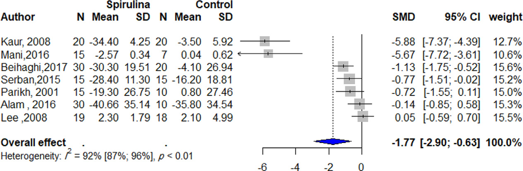

FIG 2. Forest plot of standard mean difference between Spirulina and placebo groups on

human for the effect of Spirulina supplementation on FBS.

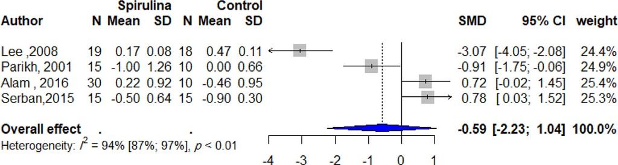

FIG 3. Forest plot of standard mean difference between Spirulina and placebo groups on

human for the effect of Spirulina supplementation on HbA1C.

Curr Probl Cardiol, October 2022

9

group. The standardized mean difference with a 95% conﬁdence interval

was obtained for TG -3.71(-6.54, -0.89) and TC -2.54 (-4.61, -0.46). In

the case of HDL-C, Arthrospira consumption signiﬁcantly increases the

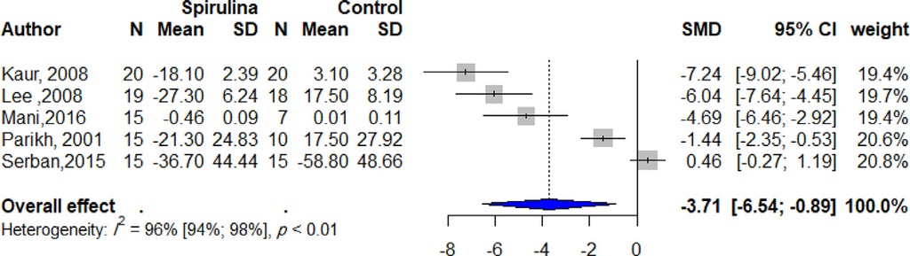

FIG 4. Forest plot of standard mean difference between Spirulina and placebo groups on

human for the effect of Spirulina supplementation on TG.

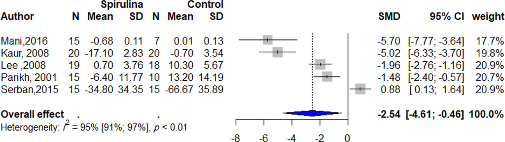

FIG 5. Forest plot of standard mean difference between Spirulina and placebo groups on

human for the effect of Spirulina supplementation on TC.

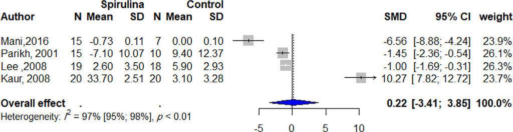

FIG 6. Forest plot of standard mean difference between Spirulina and placebo groups on

human for the effect of Spirulina supplementation on LDL-C

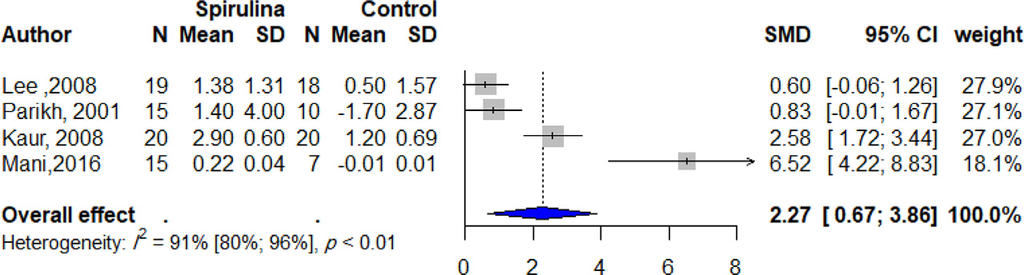

FIG 7. Forest plot of standard mean difference between Spirulina and placebo groups on

human for the effect of Spirulina supplementation on HDL-C.

10

Curr Probl Cardiol, October 2022

HDL-C level 2.27 (0.67, 3.86), however in the case of LDL-C 0.22

(-3.41, 3.85) and HbA1C -0.59 (-2.23, 1.04), no signiﬁcant difference

was observed between the two groups.

Non-clinical outcomes

except for HbA1C and FBS, other variables were not signiﬁcant. As

shown in Figures 8 and 9, the mean of HbA1C and FBS in the spirulina

group was signiﬁcantly lower than in the control group. The standardized

mean difference with 95% conﬁdence interval was obtained for HbA1C

-5.12 (-8.06, -2.19) and for FBS -10.31 (-12.49, -8.13). As shown in

Figures 10�12, the pooled result for bodyweight 3.18 (-0.13, 6.48), insu-

lin1.28 (-2.11, 4.66), and HOMA-IR -1.80 (-5.80, 2.21) were not

signiﬁcant.

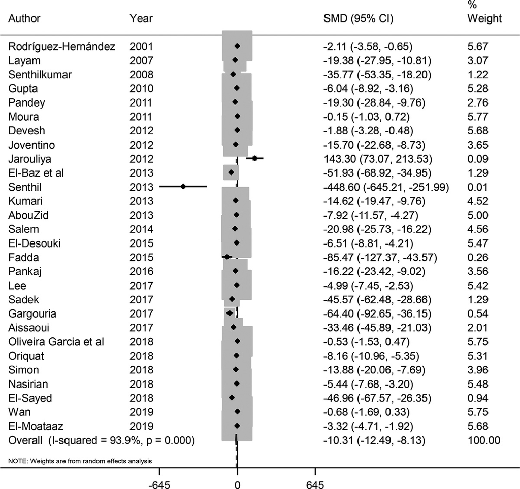

FIG 8. Forest plot of standard mean difference between Spirulina and placebo groups on rat for

the effect of Spirulina supplementation on FBS.

Curr Probl Cardiol, October 2022

11

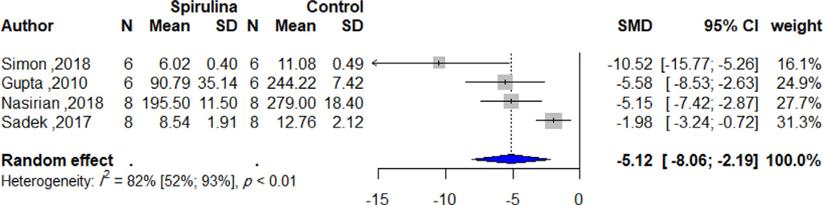

FIG 9. Forest plot of standard mean difference between Spirulina and placebo groups on rat for

the effect of Spirulina supplementation on HbA1C.

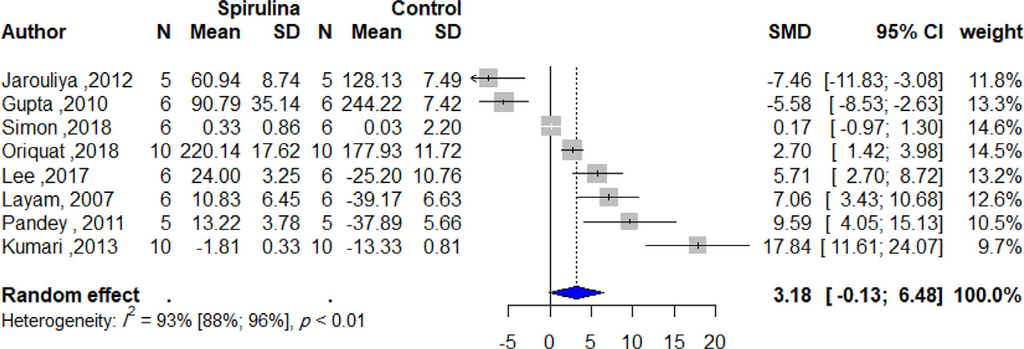

FIG 10. Forest plot of standard mean difference between Spirulina and placebo groups on rat

for the effect of Spirulina supplementation on Body weight.

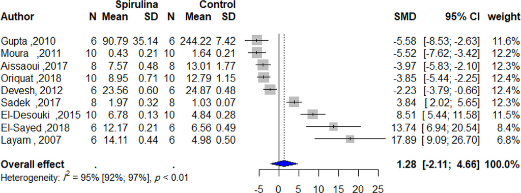

FIG 11. Forest plot of standard mean difference between Spirulina and placebo groups on rat

for the effect of Spirulina supplementation on Insulin.

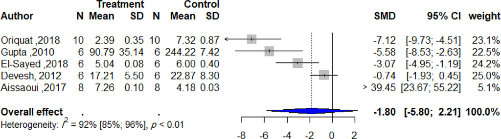

FIG 12. Forest plot of standard mean difference between Spirulina and placebo groups on rat

for the effect of Spirulina supplementation on HOMA-IR.

12

Curr Probl Cardiol, October 2022

Human sub-group analysis

Subgroup analysis was performed on two variables of drug dose (g2�

and g <2) and study duration period length (< 2 months and � 2

months). Regarding FBS study duration less than 2 months [-2.52 (-4.37,

-0.67)] and the dose less than 2 gram [-3.22 (-5.67, -0.76)] showed signif-

icant results. In terms of HbA1C, only one study with a duration of more

than 2 months showed a signiﬁcant effect of spirulina consumption on

HbA1C [-3.09 (-4.05, -2.12)]. In terms of triglycerides, cholesterol, and

LDL, only one study that had a duration of more than 2 months and a

dose of more than 2 grams showed a signiﬁcant effect of spirulina con-

sumption on reducing triglyceride [-7.37 (-9.22, -5.53)], cholesterol

[-2.01. (-2.80, -1.21)] and [LDL -1.02 (-1.71, -0.33)]. In the case of HDL,

3 studies with a duration of fewer than 2 months and a dose of less than

2 g reported a signiﬁcant effect on the increase in HDL levels.

Subgroup analysis was performed on two variables of drug dose

(<200 mg and <200 mg) and study duration (30> days and <30 days)

that in all indicators except for FBS, a signiﬁcant difference was observed

between the subgroups. In terms of weight changes, 3 studies with a dura-

tion of more than 30 days [11.93 (5.76, 18.10)] and 2 studies with a dose of

less than 200 mg reported a signiﬁcant effect of spirulina on weight gain

[8.55 (5.60, 11.50)]. In terms of insulin, only 2 studies with a dose of less

than 200 mg showed a signiﬁcant effect of [16.56 (11.33, 21.80)]. In the

case of the HOMA-IR index, there was no difference between the results

of the two subgroups in terms of study duration, but in the case of spirulina

dose, only one study with a dose of less than 200 mg showed a signiﬁcant

effect of spirulina on HOMA-IR reduction [3.33 (-5.17, -1.48)].

Discussion

In the current meta-analysis, we reviewed the evidence for the effects

of Arthrospira supplementation on the major biomarkers of glycemic con-

trol and glucose metabolism in clinical and preclinical studies. Our study

showed a signiﬁcant decrease in FBS levels both in clinical and preclini-

cal studies, and signiﬁcant improvement of TC, TG, and HDL-C levels in

clinical studies compared to the control group. Results of preclinical stud-

ies showed a signiﬁcant decrease in HbA1c levels followed by consump-

tion of spirulina.

Curr Probl Cardiol, October 2022

13

that the use of Arthrospira supplementation in patients with MetS and

related disorders caused a signiﬁcant decrease in FBS, TC, and LDL�C

and a signiﬁcant increase in HDL�C level but did not inﬂuence the TG.

studies showed great signiﬁcant effects.<sup>7</sup><sup>,</sup><sup>25</sup>Based on the results of the

mentioned studies and the pooled results of our clinical and pre-clinical

studies, it seems that spirulina supplementation decreases the FBS level

efﬁciently.

Of four clinical studies that have been evaluated the HbA1C, two

showed that spirulina decreased the HbA1C<sup>18</sup><sup>,</sup><sup>21</sup>and on the contrary two

studies reported elevated levels of HbA1C<sup>24</sup><sup>,</sup><sup>26</sup>therefore no signiﬁcant

effect on HbA1C level in clinical studies were found. Pooled results of 4

pre-clinical studies on HbA1C showed a positive effect on HbA1C level,

however, due to the small number of articles in both clinical and pre-clin-

ical lines, these results cannot be conclusively accepted and more high-

quality studies are needed to comment more conclusively.

Our sub-group analysis of clinical studies of human diabetic subjects

showed that a dose less than 2 grams of spirulina can reduce the FBS

level more effectively. A study on streptozotocin diabetic rats showed

that spirulina dose of 15 mg/kg body weight yielded better results com-

pared to the lower doses of 5 and 10 mg/kg <sup>5</sup>. They reported that spirulina

increased the hexokinase activity and decreased the glucose-6-phospha-

tase (G-6-pase) activity. The role of G-6-pase in glucose homeostasis and

T2DM was reported previously and it was mentioned that G-6-pase activ-

ity is several folds higher in diabetic animals.<sup>50</sup>Therefore decreasing the

G-6-pase followed by spirulina treatment might be one of the possible

mechanisms in adjusting FBS levels. Hexokinases is an enzyme responsi-

ble for irreversible phosphorylation of glucose to glucose-6-phosphate

and it has been reported that its’ activity is reduced in non-insulin-depen-

dent DM subjects.<sup>51</sup>Another study claimed that the mechanism of action

of spirulina may be through the increase in glucagon-like peptide-1, and

glucose-dependent insulinotropic polypeptide.<sup>52</sup>The increased activity of

NADPH oxidases in diabetic subjects also is reported and it seems that

another possible mechanism for the antidiabetic effect of Arthrospira

might be due to the down-regulation of NADPH and NADH cofactor.<sup>47</sup>

Hu et al. identiﬁed 3 peptides with the anti-diabetic activities in Arthro-

spira platensis during in-vitro studies that inﬂuence a-amylase, a-glucosi-

dase, and DPPIV which are effective components of diabetes relate

pathways<sup>8</sup>.

14

Curr Probl Cardiol, October 2022

A meta-analysis by Serban et al. on the effect of spirulina on serum

lipid proﬁle showed that spirulina reduced the TC, TG, and LDL-C and

increased the HDL-C level.<sup>20</sup>Hamedifard et al. also reported that spiru-

lina supplementation improved the TC, LDL-C, and HDL-C in patients

with MetS but not TG.<sup>22</sup>Our results proved that Arthrospira improved

the TC, TG, and HDL-C in diabetic subjects but not LDL-C. A review

study on the effect of spirulina on weight loss and lipid proﬁle showed

the positive effect of spirulina on weight loss;<sup>11</sup>however, the results of

our preclinical studies did not show any positive effect of spirulina sup-

plementation on weight loss. Subgroup analysis in preclinical studies

showed that spirulina at doses less than 200 mg cause signiﬁcant weight

gain. Zeinalian et al. in a study on obese people showed that spirulina

consumption improved the TC and HDL-C levels and also decreased the

BMI with no change in TG and LDL-C.<sup>53</sup>Another study on obese people

with BMI >25�40 kg/m2 showed a positive effect in reducing waist cir-

cumference, weight loss, body fat, and TG.<sup>54</sup>A study on the effect of Spi-

rulina on lipoprotein lipase activity showed increased activity of

lipoprotein lipase.<sup>55</sup>It was also found that spirulina intake would normal-

ize the hepatic steatosis and improve the liver function tests.<sup>56</sup>In addi-

tion, it is believed that spirulina can increase the gut microbiota which

would reduce the lipid levels by improving insulin sensitivity;<sup>56</sup>however,

our results showed no positive effect of spirulina consumption on insulin

resistance score (HOMA-IR) and insulin in preclinical studies.

Conclusion

According to the results of this study, it can be concluded that Arthro-

spira (spirulina) supplementation improved the FBS, TC, TG, and HDL-

C levels in diabetic patients and the FBS and HbA1C levels in diabetic

animals. Our results did not show any signiﬁcant positive effect on

HOMA-IR, weight loss, and insulin followed by consumption of spirulina

in animal models.

Ethical Standards

This article does not contain any studies with human participants per-

formed by any of the authors.

REFERENCES

1. Diabetes mellitus: a major risk factor for cardiovascular disease. A joint editorial

statement by the American Diabetes Association; The National Heart, Lung, and

Curr Probl Cardiol, October 2022

15

Blood Institute; The Juvenile Diabetes Foundation International; The National Insti-

tute of Diabetes and Digestive and Kidney Diseases; and The American Heart Associ-

ation. Circulation 1999;100:1132–3.

2. Vafaeimanesh J, Parham M, Norouzi S, Hamednasimi P, Bagherzadeh M. Insulin

resistance and coronary artery disease in non-diabetic patients: Is there any correla-

tion? 2018;9:121.

3. Selvin E, Coresh J, Golden SH, Boland LL, Brancati FL, Steffes MW. Glycemic con-

trol, atherosclerosis, and risk factors for cardiovascular disease in individuals with

diabetes:

the

atherosclerosis

risk

in

communities

study.

Diabetes

Care

2005;28:1965–73.

4. Standards of Medical Care in Diabetes—2016: Summary of Revisions. Diabetes Care

2016;39:S4–5.

5. Layam A, Reddy CL. Antidiabetic property of spirulina. 2006;35:29-33.

6. Oriquat GA, Ali MA, Mahmoud SA, Eid RM, Hassan R, Kamel MA, et al. Improving

hepatic mitochondrial biogenesis as a postulated mechanism for the antidiabetic effect

of Spirulina platensis in comparison with metformin. Nutrition 2019;44:357–64.

7. Mani U, Desai S, Iyer UJ, functional, foods m. Studies on the long-term effect of spi-

rulina supplementation on serum lipid proﬁle and glycated proteins in NIDDM

patients. 2000;2:25-32.

8. Hu S, Fan X, Qi P, Zhang X. Identiﬁcation of anti-diabetes peptides from Spirulina

platensis. J Funct Foods 2019;56:333–41.

9. Mohammed S, Yaqub A, Nicholas A, Arastus W, Muhammad M, Abdullahi S.

Review on diabetes, synthetic drugs and glycemic effects of medicinal plants.

2013;7:2628-37.

10. Wood D, Athwal S, Panahloo A. The advantages and disadvantages of a

‘herbal’medicine in a patient with diabetes mellitus: a case report. 2004;21:625-7.

11. DiNicolantonio JJ, Bhat AG, OKeefe J. Effects of spirulina on weight loss and blood

lipids: a review. Open heart 2020;7(1):e001003.

12. Mohan A, Misra N, Srivastav D, Umapathy D, Kumar S Spirulina, the nature’s won-

der: a review. 2014;5:7-10.

13. Manogar M, Devaraj N, Mahalingam P. A Review on Medical Properties on Spirulina

and Their Futuristic Applications. Asian Journal of Biotechnology and Bioresource

Technology. 2020:1-1.

14. Lee J, Park A, Kim MJ, Lim H, Rha Y, Kang H Spirulina extract enhanced a protec-

tive effect in type 1 diabetes by anti-apoptosis and anti-ROS production.

2017;9:1363.

15. Hirata T, Tanaka M, Ooike M, Tsunomura T, Sakaguchi M. Antioxidant activities of

phycocyanobilin prepared from Spirulina platensis. 2000;12:435-9.

16. Vazhappilly R, Chen F. Eicosapentaenoic acid and docosahexaenoic acid production

potential of microalgae and their heterotrophic growth. 1998;75:393-7.

17. Gargouri M, Hamed H, Akrouti A, Dauvergne X, Magn�e C, El Feki A, et al. Effects

of Spirulina platensis on lipid peroxidation, antioxidant defenses, and tissue damage

in kidney of alloxan-induced diabetic rats. Nutrition 2018;43:345–54.

16

Curr Probl Cardiol, October 2022

18. Parikh P, Mani U, Iyer U. Role of Spirulina in the control of glycemia and lipidemia

in type 2 diabetes mellitus. 2001;4:193-9.

19. Tiwari AK, Tiwari BJ. Cyanotherapeutics: an emerging ﬁeld for future drug discov-

ery. 2020;1:1-14.

20. Serban M-C, Sahebkar A, Dragan S, Stoichescu-Hogea G, Ursoniu S, Andrica F, et al.

A systematic review and meta-analysis of the impact of Spirulina supplementation on

plasma lipid concentrations. 2016;35:842-51.

21. Lee EH, Park J-E, Choi Y-J, Huh K-B, Kim W-Y, Practice. A randomized study to

establish the effects of spirulina in type 2 diabetes mellitus patients. 2008;2:295-300.

22. Hamedifard Z, Milajerdi A, Reiner <sup>�</sup>Z, Taghizadeh M, Kolahdooz F, Asemi ZJ. The

effects of spirulina on glycemic control and serum lipoproteins in patients with meta-

bolic syndrome and related disorders: A systematic review and meta-analysis of ran-

domized controlled trials. 2019;33:2609-21.

23. Liberati A, Altman DG, Tetzlaff J, Mulrow C, Gøtzsche PC, Ioannidis JP, et al. The

PRISMA statement for reporting systematic reviews and meta-analyses of studies

that evaluate health care interventions: explanation and elaboration. Ann Intern Med

2009;151. W-65-W-94.

24. Alam A, Quamri S, Fatima S, Roqaiya M, Ahmad Z, metabolism. issn JDM. Efﬁcacy

of Spirulina (Tahlab) in Patients of Type 2 Diabetes Mellitus (Ziabetus Shakri)-A

Randomized Controlled Trial. 2016;7:6155-6.

25. Kaur K, Sachdeva R, Grover K, Foods, Sciences H. Effect of supplementation of Spi-

rulina on blood glucose and lipid proﬁle of the non-insulin dependent diabetic male

subjects. 2008;27:202-8.

26. Serban M-C, Stoichescu-hogea G, Gurban C, Petcu F, Jeyakumar D, Andrica F, et al.

The role of Spirulina platensis in the control of type 2 diabetes mellitus. 1982;96:27.

27. Beihaghi M, Taherzadeh Z, Metabolism. The effects of oral administration of spiru-

lina platensis (cultured iranian) on blood glucose and glycosylated hemoglobin blood

in type ii diabetes mellitus patients. 2017;16:183-90.

28. Rodrıguez-Hern�andez A, Ble-Castillo J, Juarez-Oropeza M, Dıaz-Zagoya J. Spirulina

maxima prevents fatty liver formation in CD-1 male and female mice with experi-

mental diabetes. 2001;69:1029-37.

29. Senthilkumar R, John S Hypoglycaemic activity of marine cyanobacteria in alloxan

induced diabetic rats. 2008;2:704-14.

30. Gupta S, Hrishikeshvan H, Sehajpal P, practice c. Spirulina protects against Rosiglita-

zone induced osteoporosis in insulin resistance rats. 2010;87:38-43.

31. Pandey JP, Tiwari A, Mishra G, Mishra R. Role of Spirulina maxima in the control of

blood glucose levels and body weight in streptozotocin induced diabetic male Wistar

rats. 2011;2:35-7.

32. Moura LP, Puga GM, Beck WR, Teixeira IP, Ghezzi AC, Silva GA, et al. Exercise

and spirulina control non-alcoholic hepatic steatosis and lipid proﬁle in diabetic Wis-

tar rats. 2011;10:77.

33. Devesh C, Kritika M, Anroop N, Kumar S, Sumeet G Spirulina reverses histomorpho-

logical changes in diabetic osteoporosis in pioglitazone treated rats. 2012;1:1-7.

Curr Probl Cardiol, October 2022

17

34. Joventino IP, Alves HG, Neves LC, Pinheiro-Joventino F, Leal LK, Neves SA, et al.

The microalga Spirulina platensis presents anti-inﬂammatory action as well as hypo-

glycemic and hypolipidemic properties in diabetic rats. J Complement Integr Med

2012;9:17. https://doi.org/10.1515/1553-3840.1534.

35. Jarouliya U, Anish ZJ, Kumar P, Bisen P, Prasad G. Alleviation of metabolic abnor-

malities induced by excessive fructose administration in Wistar rats by Spirulina

maxima. 2012;135:422.

36. El-Baz F, Aly HF, El-Sayed A, Mohamed A Role of Spirulina platensis in the control

of glycemia in DM2 rats. 2013;4:1731-40.

37. Senthil N, Balu P, Murugesan K Antihyperglycemic effect of spirulina, insulin and

Morinda citrifolia against streptozotocin induced diabetic rats. 2013;2:537-59.

38. AbouZid SF, Ahmed OM, Ahmed RR, Mahmoud A, Abdella E, Ashour M. Antihyper-

glycemic effect of crude extracts of some Egyptian plants and algae. 2014;17:400-6.

39. Salem SI, Ibrahim A, El-Olemy KA, Mosleh MI. Clinicopathological Studies on the

Use of Spirulina platensis as a Modern Food Supplement in Alloxan-induced Diabetic

Rats.

40. El-Desouki N, Tabl G, Abdel-Aziz K, Salim E, Nazeeh N, Zoology A Improvement

in beta-islets of Langerhans in alloxan-induced diabetic rats by erythropoietin and

Spirulina. 2015;71:20-31.

41. Fadda WA, Mansour FK, El-Safti FA, El-Sayed IH, El-Mehi A. Ameliorative effect

of spirulina against streptozotocin-induced diabetic changes in the pancreas of adult

male albino rats: a histological, immunohistochemical, and molecular study.

2015;38:427-37.

42. Pankaj P, Research. Cell Suspension of Spirulina platensis Partially Attenuates

Alloxan Induced Alterations in Carbohydrate and Lipid Metabolism In Diabetic

Mice. 2016;7:2805.

43. Aissaoui O, Amiali M, Bouzid N, Belkacemi K, Bitam A Effect of Spirulina platensis

ingestion on the abnormal biochemical and oxidative stress parameters in the pan-

creas and liver of alloxan-induced diabetic rats. 2017;55:1304-12.

44. Garcia FAdO, Yuen VG, Campos HSd, Turatti E, Viana GSdB, Oliveira CJF, et al. Spi-

rulina platensis alleviates the liver, brain and heart oxidative stress in Type 1 diabetic

rats. Food Nutr Sci 2018;9(6).

45. Simon JP, Baskaran UL, Shallauddin KB, Ramalingam G, Prince S Evidence of anti-

diabetic activity of Spirulina fusiformis against streptozotocin-induced diabetic Wis-

tar albino rats. 2018;8:129.

46. Nasirian F, Dadkhah M, Moradi-kor N, Obeidavi Z, metabolic syndrome, targets o,

therapy. Effects of Spirulina platensis microalgae on antioxidant and anti-inﬂamma-

tory factors in diabetic rats. 2018;11:375.

47. El-Sayed E-SM, Hikal M, Abo El-Khair B, El-Ghobashy R, El-Assar A. Hypoglyce-

mic and hypolipidemic effects of spirulina platensis, phycocyanin, phycocyanopep-

tide and phycocyanobilin on male diabetic rats. 2018;26(Special issue (2A)):1121-34.

48. Wan X-z, Li T-t, Zhong R-t, Chen H-b, Xia X, Gao L-y, et al. Anti-diabetic activity of

PUFAs-rich extracts of Chlorella pyrenoidosa and Spirulina platensis in rats.

2019;128:233-9.

18

Curr Probl Cardiol, October 2022

49. El-Moataaz S, Ismael H, Aborhyem S. Assessment of Chemical Composition of Spi-

rulina Platensis and its Effect on Fasting Blood Glucose and Lipid Proﬁle in Diabetic

Rats. 2019;49:199-211.

50. Westergaard N, Madsen P. Glucose-6-phosphatase inhibitors for the treatment of type

2 diabetes. 2001;11:1429-41.

51. Vestergaard H, Bjørbaek C, Hansen T, Larsen FS, Granner DK, Pedersen O. Impaired

activity and gene expression of hexokinase II in muscle from non-insulin-dependent

diabetes mellitus patients. J Clin Invest 1995;96:2639–45.

52. Okechukwu PN, Ekeuku SO, Sharma M, Nee CP, Chan HK, Mohamed N, et al. In

vivo and in vitro antidiabetic and antioxidant activity of spirulina. 2019;15:17.

53. Zeinalian R, Farhangi MA, Shariat A, Saghaﬁ-Asl M, medicine a. The effects of Spi-

rulina Platensis on anthropometric indices, appetite, lipid proﬁle and serum vascular

endothelial growth factor (VEGF) in obese individuals: a randomized double blinded

placebo controlled trial. 2017;17:225.

54. Youseﬁ R, Mottaghi A, Saidpour A. Spirulina platensis effectively ameliorates

anthropometric measurements and obesity-related metabolic disorders in obese or

overweight healthy individuals: A randomized controlled trial. 2018;40:106-12.

55. Iwata K, Inayama T, Kato T, Vitaminology. Effects of Spirulina platensis on plasma

lipoprotein lipase activity in fructose-induced hyperlipidemic rats. 1990;36:165-71.

56. Li T-T, Liu Y-Y, Wan X-Z, Huang Z-R, Liu B, Zhao C. Regulatory efﬁcacy of the

polyunsaturated fatty acids from microalgae spirulina platensis on lipid metabolism

and gut microbiota in high-fat diet rats. 2018;19:3075.

57. Kumari P. In vivo clinical study of spirulina as a antidiabatic. Int J Pharm Arch

2013;2(7):165–72.

Curr Probl Cardiol, October 2022

19